# Tvyal Newsletter

Aghasi Tavadyan

2023-10-23

*English summary below.*

Հարգելի գործընկեր,

Հուսով եմ լավ եք: Ներկայացնում եմ անցած շաբաթվա վերլուծությունները և աշխատանքները.

1. Ռուսաստանի Դաշնության բյուջեի կատարումը
2. ԶԼՄ հաղորդակցություններ, ինչ սպասել
3. English summary

## 1. Ռուսաստանի Դաշնության բյուջեի կատարումը

Այս հաղորդագրությունը մեր կողմից կատարված նախորդ 2 հաղորդագրությունների շարունակությունն է

1. [Ռուսաստանի տնտեսության վիճակը և դրա հնարավոր ազդեցությունը տարածաշրջանի վրա](https://www.tvyal.com/newsletter/2023_10_03), 2023-10-03
2. [Ռուսական ռուբլին ամրանալու է։ Արտարժույթի հնարավոր հոսքը Ռուսատանից Հայաստան](https://www.tvyal.com/newsletter/2023_10_16), 2023-10-16

Ռուսական տնտեսության ուսումնասիրությունը, ինչպես ներկայացված է, կենսական նշանակություն ունի Հայաստանի համար մի քանի պատճառներով: Նախ հայատանի արտահանման մոտ 55 տոկոսը այս պահին գնում է դեպի ՌԴ, ռուբլու պոտենցիալ ամրապնդումը կարող է անրադառնել տնտեսական ակտիվության արտահանման և այլ տնտեսական ցուցանիշների վրա։ Բացի այդ, ռուսական վերջին քաղաքականությունը, որն ուղղված է իր շուկայում արտարժույթի քանակի ավելացմանը, կարող է ռուսական զգալի քանակությամբ կապիտալի ներհոսք ապահովել դեպի Հայաստան։ Սա հնարավոր է խթան հանդիսանալ Հայաստանի տնտեսության և բանկային համակարգի համար, ինչը հատկապես կարևոր է երկրի ներկայիս տնտեսական մարտահրավերների պայմաններում։ Հետևաբար, Ռուսաստանի տնտեսական միտումների հետազոտությունը չափազանց կարևոր է Հայաստանի համար, քանի որ այն ուղղակիորեն ազդում է արտարժույթի հոսքի և այլ տնտեսական ցուցանիշների վրա: [Ավելին՝ 2.](https://www.tvyal.com/newsletter/2023_10_16)։

*Գծապատկեր 1.* Ռուսաստանի բյուջեի եկամուտների դինամիկան (մլրդ ռուբլի, տարեկան ցուցանիշ)

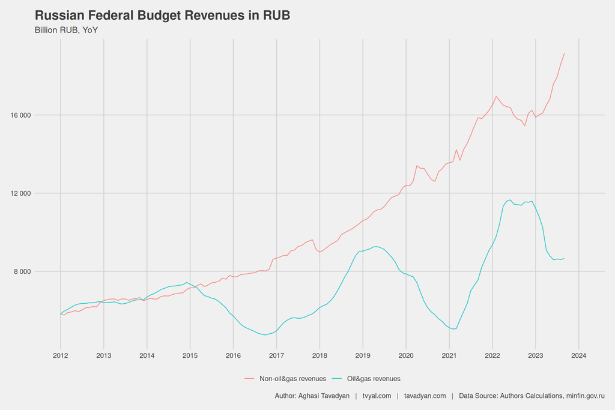

Երկրորդ գծապատկերում ներկայացված է համեմատություն դոլարով եկամտի և ռուբլու փոխարժեքի միջև, որը լույս է սփռում որոշ հարցերի շուրջ: Այստեղ ամսական եկամտը ռուբլով բաժանվել են համապատասխան ամսվա միջին փոխարժեքի վրա, ստացված ցուցանիշը գումարվել է նախորդ 12 ամսվա կտրվածքով արդյունքում:

Գծապատկերի վերևի հատվածում ցուցադրված էԱՄՆ դոլար / ՌԴ ռուբլի փոխարժեքը, իսկ ներքևի Ռուսաստանի Դաշնության բյուջեի եկամուտները՝ տարեկան կտրվածքով և արտահայտված դոլարով: Եկամուտների տվյալները բաժանված են երկու մասի՝ նավթամթերքից և գազից ստացված եկամուտ և ոչ նավթային ապրանքներից եկամուտ: Այս գծապատկերից երևում է ինչպես զգայուն ազդեցություն ունի ռուսական ռուբլու փոխարժեքը, մասնավորապես, նավթամթերքի արտահանումից ստացվող եկամուտներց:

*Գծապատկեր 2.* Ռուբլու փոխարժեքի դինամիկան և ՌԴ բյուջեի եկամուտները (մլրդ ԱՄՆ դոլար տարեկան ցուցանիշ)։

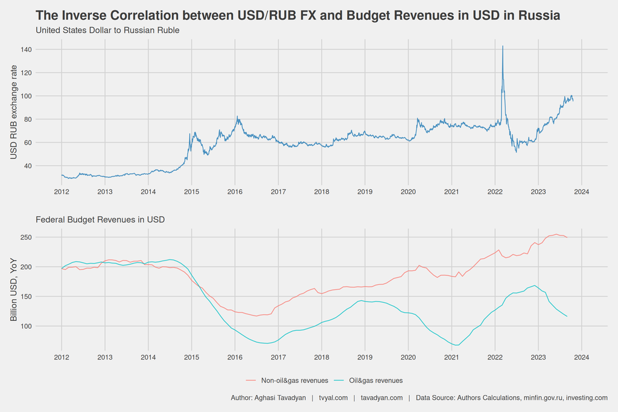

*Գծապատկեր 3.* Ռուսական ռուբլու րտարժույթի և ԱՄՆ դոլարով բյուջետային եկամուտների միջև հակադարձ կորելացիան

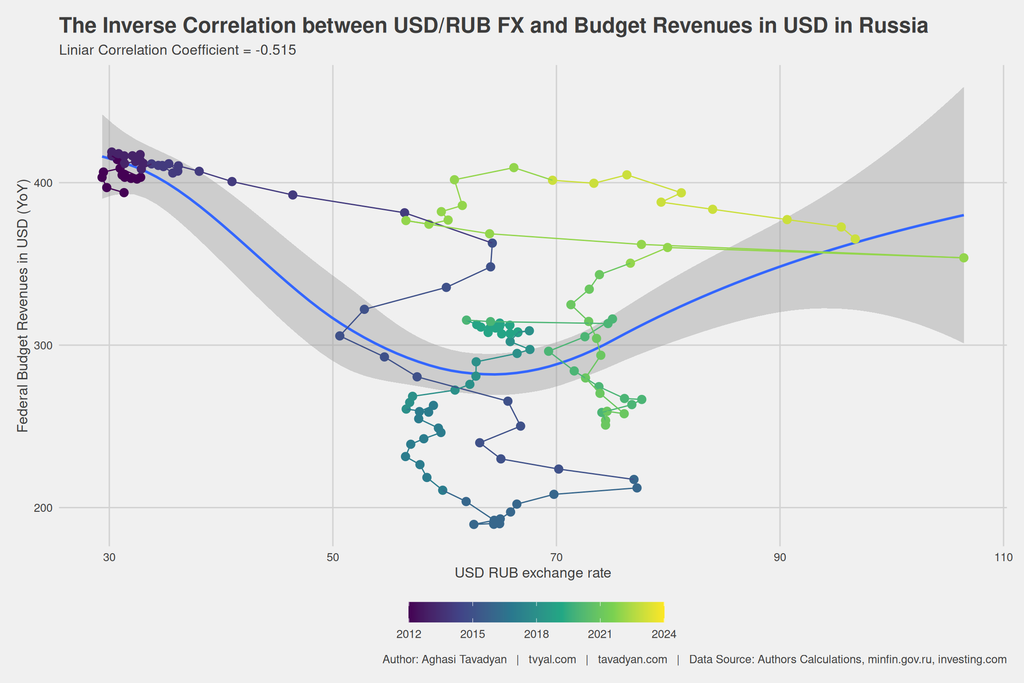

4-րդ գծապատկերում ցույց է տրված Ռուսաստանի եկամուտների և ծախսերի 12 ամսվա հարաբերակցությունը: Ներկայումս ակնհայտ է, որ Ռուսաստանն ավելի շատ է ծախսում, քան ստանում եկամուտ։ Այնուամենայնիվ, 2023թ սեպտեմբերի կտրվածքով այս հարաբերակցությունը արդեն ունի աճի միտում, ինչը կարող է վկայել մոտ ապագայում ֆինանսական հաշվեկշռի հնարավոր բարելավման մասին:

*Գծապատկեր 4.* Ռուսաստանի բյուջետային եկամուտների և ծախսերի հարաբերակցությունը։

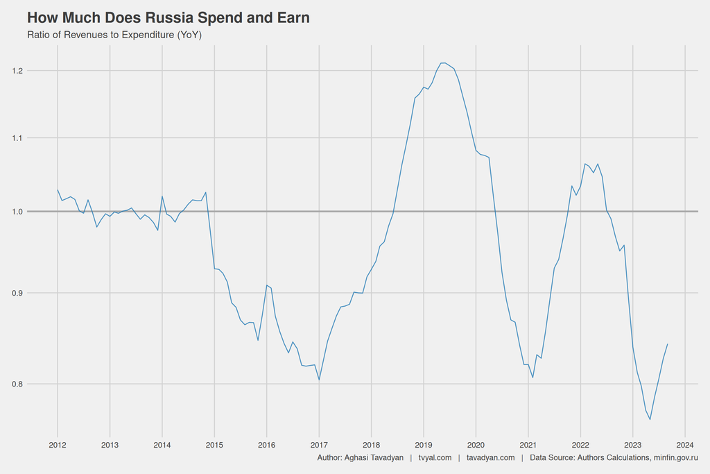

*Գծապատկեր 5.* Ռուսաստանի բյուջեի եկամուտների հարաբերակցությունը։

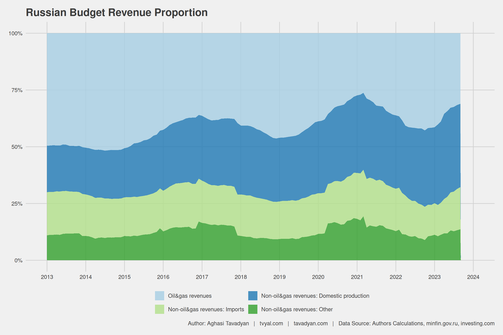

Հաշվի առնելով այս ցիկլայինությունը և Ռուսաստանի Դաշնության երկակի իրարամերժ նպատակները, որնք են ռուբլու արժևորմանը և միաժամանակ բենզինի վաճառքից ստացվող եկամուտների ավելացմանը՝ հավանական է, որ հաջորդ տարվա ընթացքում Ռուսաստանը կարող է հաստատվել նոր շուկաներում, որը կարող է բերել նավթամթերքի և ազի վաճառքից ստացվող երկամուտնեի աճին։

## 2. ԶԼՄ հաղորդակցություններ, ինչ սպասել

Այս շաբաթ տվել եմ հարցազրույց 1in.am-ին ռուսական ռուբլու փոխարժեքի կանխատեսման և Հայաստանում տնտեսական հնարավոր փոփոխությունների մաիսն։

Հարցազրույցները կտան հետևյալ հարցերի պատասխանները․

- Ռուսական ռուբլին ամրանալու է։ Արտարժույթի հնարավոր հոսքը Ռուսատանից Հայաստան։
- Հայաստանից Միջազգային դրամական փոխանցումների վերլուծություն:
- Ի՞նչ կապ ունի ՌԴ տնտեսական ճգնաժամը Արցախի հետ:
- Ի՞նչ նոր շոկեր և դրական ազդակներ կարող են սպասել Հայաստանին:
- Ի՞նչ է մեզ սպասվում:
- Ի՞նչ անել տնտեսության և պետության ամրապնդման համար:

[Այս խնդրի մասին ավելին տեղեկանալու համար դիտեք հարցազրույցը](https://www.youtube.com/watch?v=9w7Sfg73fxI)

[figure not shown]

## 3. English Summary

this we we analized the financial dynamics of Russia’s budget, where we delve into a series of compelling charts. In “Chart 1,” we explore the fascinating evolution of Russian budget revenues, highlighting the transition from heavy reliance on oil and gas income to the emergence of non-oil revenues. The impact of global oil prices, the COVID-19 pandemic, and sanctions on Russia is clearly illustrated. “Chart 2” takes us on a journey through the interplay between exchange rates and Russian budget income in USD, revealing the critical role the ruble’s exchange rate plays in shaping the nation’s finances.

Այս վերլուծությունը առկա է նաև [մեր կայքեջում](https://www.tvyal.com/newsletter/2023_10_23), այս վերլուծության կոդը դրված է նաև [Github-ում](https://github.com/tavad/tvyal_newsletter)։

Եթե հնարավոր է, խնդրում եմ այս նյութը ուղարկել նաև այն մարդկանց, ում այն կարծում եք կարող է հետաքրքրել:

Սպասեք հաջորդ հաղորդագրությանը մի շաբաթվա ընթացքում:

Հարգանքներով,  
Աղասի Թավադյան  
23.10.2023  
[tvyal.com](https://www.tvyal.com/)  
[tavadyan.com](https://www.tavadyan.com/)

**Ուշադրություն. Ձեր էլ.փոստը մեյլիսթի մեջ է, որի միջոցով ես կիսվում եմ շաբաթական նյութեր, որոնք հիմնականում ներկայացնում են Հայաստանի տնտեսությանը: Նյութերը ներառում են գծապատկերներ, [տվյալների բազաներ](https://github.com/tavad/tvyal_newsletter), տեսանյութեր, հոդվածներ, [առցանց վահանակներ](https://www.tvyal.com/projects), տնտեսական գործիքներ, կանխատեսումներ և հաշվետվություններ: Եթե ցանկանում եք չեղարկել բաժանորդագրությունը, խնդրում եմ տեղեկացրեք ինձ, և ես կհեռացնեմ ձեր էլ. փոստը ցուցակից: Գրեք նաև եթե ունեք մենկնաբանություններ:**

**Important! Your email is part of the mailing list where I share weekly materials primarily focused on the Armenian economy. These materials encompass charts, [databases](https://github.com/tavad/tvyal_newsletter), videos, articles, [online dashboards](https://www.tvyal.com/projects), economic tools, forecasts, and reports. If you wish to unsubscribe, please let me know, and I will remove your email from the list. Please share your comments as well․**